# Notebook

## Week 2B: Data Visualization Fundamentals

Sep 10, 2020

## Housekeeping

- HW #1 due today
- HW #2 has been posted — due in **two weeks**
- Lots of good questions on Piazza so far!
  - Email me if you need access: https://piazza.com/upenn/fall2020/musa550

**Reminder:** Links to course materials and main sites (Piazza, Canvas, Github) can be found on the home page of the main course website:

**https://musa-550-fall-2020.github.io/**

## Help with file paths and working directories

Eugene put up a great post on Piazza walking through somes tips for managing your folder structure on your laptop:

https://piazza.com/class/ke999wuhrls2t8?cid=29

## Reminder: Office Hours

- Nick: Tuesdays 7:30am-9am and 6pm-7:30pm
- Eugene: Thursday, 10:30am-12:30pm
- Sign-up for time slots on **Canvas calendar**

## Reminder: Course Schedule

- There was no class on Tuesday — a pre-recorded lecture for 2A can be found on Canvas under "Class Recordings"
- Moving forward, a *pre-recorded* lecture will be uploaded Sunday evenings and will replace the synchronous Zoom lecture on Tuesday

## Week #2

- **Week #2 repository:** https://github.com/MUSA-550-Fall-2020/week-2
- Recommended readings for the week listed here
- Last Tuesday
  - A brief overview of data visualization
  - Practical tips on color in data vizualization
  - The Python landscape:
    - [matplotlib](https://matplotlib.org/)
    - [seaborn](https://seaborn.pydata.org/)
- Today
  - Adding interaction to our plots!
  - Intro to the [Altair](https://altair-viz.github.io/) package
  - Lab: Reproducing a famous Wall Street data visualization with Altair

## Reminder: following along with lectures

### Easiest option: Binder

[figure not shown]

### Harder option: downloading Github repository contents

[figure not shown]

## Let's load the Palmer Penguins data set

We'll use the [Palmer penguins](https://github.com/allisonhorst/palmerpenguins) data set, data collected for three species of penguins at Palmer station in Antartica

[figure not shown]

Artwork by [@allison_horst](https://github.com/allisonhorst)

```python
import pandas as pd
```

```python
# Load data on Palmer penguins
penguins = pd.read_csv("./data/penguins.csv")
penguins.head(n=10)
```

|  | species | island | bill_length_mm | bill_depth_mm | flipper_length_mm | body_mass_g | sex | year |
| --- | --- | --- | --- | --- | --- | --- | --- | --- |
| 0 | Adelie | Torgersen | 39.1 | 18.7 | 181.0 | 3750.0 | male | 2007 |
| 1 | Adelie | Torgersen | 39.5 | 17.4 | 186.0 | 3800.0 | female | 2007 |
| 2 | Adelie | Torgersen | 40.3 | 18.0 | 195.0 | 3250.0 | female | 2007 |
| 3 | Adelie | Torgersen | NaN | NaN | NaN | NaN | NaN | 2007 |
| 4 | Adelie | Torgersen | 36.7 | 19.3 | 193.0 | 3450.0 | female | 2007 |
| 5 | Adelie | Torgersen | 39.3 | 20.6 | 190.0 | 3650.0 | male | 2007 |
| 6 | Adelie | Torgersen | 38.9 | 17.8 | 181.0 | 3625.0 | female | 2007 |
| 7 | Adelie | Torgersen | 39.2 | 19.6 | 195.0 | 4675.0 | male | 2007 |
| 8 | Adelie | Torgersen | 34.1 | 18.1 | 193.0 | 3475.0 | NaN | 2007 |
| 9 | Adelie | Torgersen | 42.0 | 20.2 | 190.0 | 4250.0 | NaN | 2007 |

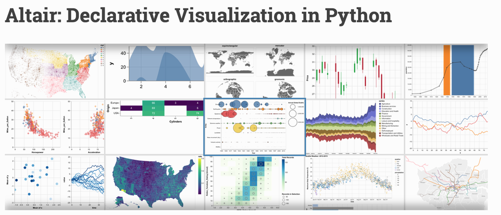

## The altair import statement

```python
import altair as alt
```

## A visualization grammar

- Specify *what* should be done
- Details determined automatically
- Charts are really just *visualization specifications* and the *data* to make the plot
- Relies on [vega](https://vega.github.io/vega/) and [vega-lite](https://vega.github.io/vega-lite/)

**Important:** focuses on *tidy* data — you'll often find yourself running `pd.melt()` to get to tidy format

Let's try out our flipper length vs bill length example from last lecture...

```python
# initialize the chart with the data
chart = alt.Chart(penguins)

# define what kind of marks to use
chart = chart.mark_circle(size=60)

# encode the visual channels
chart = chart.encode(
    x="flipper_length_mm",
    y="bill_length_mm",
    color="species",
    tooltip=["species", "flipper_length_mm", "bill_length_mm", "island", "sex"],
)

# make the chart interactive
chart.interactive()
```

[interactive chart not shown]

## Altair shorcuts

- There are built-in objects to represent "x", "y", "color", "tooltip", etc..
- Using the object syntax allows your to customize how different elements behave

**Example:** previous code is the same as

```
chart = chart.encode(
    x=alt.X("flipper_length_mm"),
    y=alt.Y("bill_length_mm"),
    color=alt.Color("species"),
    tooltip=alt.Tooltip(["species", "flipper_length_mm", "bill_length_mm", "island", "sex"]),
)
```

## Changing Altair chart axis limits

- By default, Altair assumes the axis will start at 0
- To center on the data automatically, we need to use a `alt.Scale()` object to specify the scale

```python
# initialize the chart with the data
chart = alt.Chart(penguins)

# define what kind of marks to use
chart = chart.mark_circle(size=60)

# encode the visual channels
chart = chart.encode(
    x=alt.X("flipper_length_mm", scale=alt.Scale(zero=False)),
    y=alt.Y("bill_length_mm", scale=alt.Scale(zero=False)),
    color="species",
    tooltip=["species", "flipper_length_mm", "bill_length_mm", "island", "sex"],
)

# make the chart interactive
chart.interactive()
```

[interactive chart not shown]

## Encodings

- X: x-axis value
- Y: y-axis value
- Color: color of the mark
- Opacity: transparency/opacity of the mark
- Shape: shape of the mark
- Size: size of the mark
- Row: row within a grid of facet plots
- Column: column within a grid of facet plots

For a complete list of these encodings, see the [Encodings](https://altair-viz.github.io/user_guide/encoding.html) section of the documentation.

Altair charts can be fully specified as JSON $\rightarrow$ easy to embed in HTML on websites!

```python
# Save the chart as a JSON string!
json = chart.to_json()
```

```python
# Print out the first 1,000 characters
print(json[:1000])
```

```
{
  "$schema": "https://vega.github.io/schema/vega-lite/v4.8.1.json",
  "config": {
    "view": {
      "continuousHeight": 300,
      "continuousWidth": 400
    }
  },
  "data": {
    "name": "data-d00e1631cca48c544438d30d2b470e8a"
  },
  "datasets": {
    "data-d00e1631cca48c544438d30d2b470e8a": [
      {
        "bill_depth_mm": 18.7,
        "bill_length_mm": 39.1,
        "body_mass_g": 3750.0,
        "flipper_length_mm": 181.0,
        "island": "Torgersen",
        "sex": "male",
        "species": "Adelie",
        "year": 2007
      },
      {
        "bill_depth_mm": 17.4,
        "bill_length_mm": 39.5,
        "body_mass_g": 3800.0,
        "flipper_length_mm": 186.0,
        "island": "Torgersen",
        "sex": "female",
        "species": "Adelie",
        "year": 2007
      },
      {
        "bill_depth_mm": 18.0,
        "bill_length_mm": 40.3,
        "body_mass_g": 3250.0,
        "flipper_length_mm": 195.0,
        "island": "Torgersen",
        "sex": "female",
```

## Publishing the visualization online

```python
chart.save("chart.html")
```

```python
# Display IFrame in IPython
from IPython.display import IFrame
IFrame('chart.html', width=600, height=375)
```

[interactive chart not shown]

## Usually, the function calls are *chained* together

```python
chart = (
    alt.Chart(penguins)
    .mark_circle(size=60)
    .encode(
        x=alt.X("flipper_length_mm", scale=alt.Scale(zero=False)),
        y=alt.Y("bill_length_mm", scale=alt.Scale(zero=False)),
        color="species:N",
    )
    .interactive()
)

chart
```

[interactive chart not shown]

Note that the `interactive()` call allows users to pan and zoom.

Altair is able to automatically determine the type of the variable using built-in heuristics. Altair and Vega-Lite support four primitive data types:

| Data Type | Code | Description |
| --- | --- | --- |
| quantitative | Q | Numerical quantity (real-valued) |
| nominal | N | Name / Unordered categorical |
| ordinal | O | Ordered categorial |
| temporal | T | Date/time |

## Faceting

Easily create multiple views of a dataset.

```python
alt.Chart(penguins).mark_point().encode(
    x=alt.X("flipper_length_mm:Q", scale=alt.Scale(zero=False)),
    y=alt.Y("bill_length_mm:Q", scale=alt.Scale(zero=False)),
    color="species:N"
).properties(
    width=200, height=200
).facet(column="species").interactive()
```

[interactive chart not shown]

Note: I've added the variable type identifiers (Q, N) to the previous example

Lots of features to create *compound charts*: repeated charts, faceted charts, vertical and horizontal stacking of subplots.

See the [documentation](https://altair-viz.github.io/user_guide/compound_charts.html) for examples

## A grammar of interaction

A relatively new addition to altair, vega, and vega-lite. This allows you to define what happens when users interact with your visualization.

## A faceted plot, now with interaction!

```python
# create the selection box
brush = alt.selection_interval()


alt.Chart(penguins).mark_point().encode(
    x=alt.X(
        "flipper_length_mm", scale=alt.Scale(zero=False)
    ), # x
    y=alt.Y(
        "bill_length_mm", scale=alt.Scale(zero=False)
    ), # y
    color=alt.condition(
        brush, "species", alt.value("lightgray")
    ), # color
    tooltip=["species", "flipper_length_mm", "bill_length_mm"],
).properties(
    width=200, height=200, selection=brush
).facet(column="species")
```

[interactive chart not shown]

## Selecting across multiple variables

Let's examine the relationship between `flipper_length_mm`, `bill_length_mm`, and `body_mass_g`

We'll use [a repeated chart](https://altair-viz.github.io/user_guide/compound_charts.html#repeat-chart) that repeats variables across rows and columns.

Use a conditional color again, based on a brush selection.

```python
# Setup the selection brush
brush = alt.selection(type='interval', resolve='global')

# Setup the chart
alt.Chart(penguins).mark_circle().encode(
    alt.X(alt.repeat("column"), type='quantitative', scale=alt.Scale(zero=False)),
    alt.Y(alt.repeat("row"), type='quantitative', scale=alt.Scale(zero=False)),
    color=alt.condition(brush, 'species:N', alt.value('lightgray')), # conditional color
).properties(
    width=200,
    height=200,
    selection=brush
).repeat( # repeat variables across rows and columns
    row=['flipper_length_mm', 'bill_length_mm', 'body_mass_g'],
    column=['body_mass_g', 'bill_length_mm', 'flipper_length_mm']
)
```

[interactive chart not shown]

## More exploratory visualization

Let's explore the relationship between flipper length, body mass, and sex.

> Scatter flipper length vs body mass for each species, colored by sex

```python
alt.Chart(penguins).mark_point().encode(
    x=alt.X('flipper_length_mm', scale=alt.Scale(zero=False)),
    y=alt.Y('body_mass_g', scale=alt.Scale(zero=False)),
    color=alt.Color("sex:N", scale=alt.Scale(scheme="Set2")),
).properties(
    width=400, height=150
).facet(row='species')
```

[interactive chart not shown]

## Note: Changing the color scheme

I've specified the `scale` keyword to the `alt.Color()` object and passed a `scheme` value:

```
scale=alt.Scale(scheme="Set2")
```

`Set2` is a Color Brewer color. The available color schemes are very similar to those matplotlib. A list is available on the Vega documentation: https://vega.github.io/vega/docs/schemes/.

> Next, plot the total number of penguins per species by the island they are found on.

```python
alt.Chart(penguins).mark_bar().encode(
    x=alt.X('*:Q', aggregate='count',  stack='normalize'),
    y='island:N',
    color='species:N',
    tooltip=['island','species', 'count(*):Q']
)
```

[interactive chart not shown]

> Plot a histogram of number of penguins by flipper length, grouped by species.

```python
alt.Chart(penguins).mark_bar().encode(
    x=alt.X('flipper_length_mm', bin=alt.Bin(maxbins=20)),
    y='count(*):Q',
    color='species',
    tooltip=['species', alt.Tooltip('count()', title='Number of Penguins')]
).properties(
    height=250
)
```

[interactive chart not shown]

> Finally, let's bin the data by body mass and plot the average flipper length per bin, colored by the species.

```python
alt.Chart(penguins.dropna()).mark_line().encode(
    x=alt.X("body_mass_g:Q", bin=alt.Bin(maxbins=10)),
    y=alt.Y('mean(flipper_length_mm):Q', scale=alt.Scale(zero=False)), # apply a mean to the flipper length in each bin
    color='species:N',
    tooltip=['mean(flipper_length_mm):Q', "count():Q"]
).properties(
    height=300,
    width=500
)
```

[interactive chart not shown]

In addition to `mean()` and `count()`, you can apply a number of different transformations to the data before plotting, including binning, arbitrary functions, and filters.

See the [Data Transformations](https://altair-viz.github.io/user_guide/transform/index.html) section of the user guide for more details.

## Dashboards become easy to make...

```python
# Setup a brush selection
brush = alt.selection(type='interval')

# The top scatterplot: flipper length vs bill length
points = alt.Chart().mark_point().encode(
    x=alt.X('flipper_length_mm:Q', scale=alt.Scale(zero=False)),
    y=alt.Y('bill_length_mm:Q', scale=alt.Scale(zero=False)),
    color=alt.condition(brush, 'species:N', alt.value('lightgray'))
).properties(
    selection=brush,
    width=800
)

# the bottom bar plot
bars = alt.Chart().mark_bar().encode(
    x='count(species):Q',
    y='species:N',
    color='species:N',
).transform_filter(
    brush.ref() # the filter transform uses the selection
                # to filter the input data to this chart
).properties(
width=800
)

chart = alt.vconcat(points, bars, data=penguins) # vertical stacking
chart
```

[interactive chart not shown]

## Now onto a more interesting example

**Exercise**: let's reproduce this famous Wall Street Journal visualization showing measles incidence over time.

http://graphics.wsj.com/infectious-diseases-and-vaccines/

## Step 1: Load the data

### First confirm the local path of the Jupyter notebook

- Use two command line functions: `pwd` and `ls`
- Don't forget you need a ! before the command to tell Jupyter it's a command line function

```python
# Print out the current working directory
! pwd
```

```
/Users/nhand/Teaching/PennMUSA/Fall2020/week-2
```

```python
# List all of the current working directories
! ls
```

```
README.md
altair-data-ca57ab90d3f95b1c80eba4532570d68b.json
altair-data-d676c5169a80f978f8cf008b5d336e79.json
altair-data-f120b4a93567957066f3d75b4b5cdc6f.json
chart.html
data
environment.yml
lecture-2A.html
lecture-2A.ipynb
lecture-2B-solutions.ipynb
lecture-2B.html
lecture-2B.ipynb
outline.md
```

```python
url = 'data/measles_incidence.csv' # this is a relative path
data = pd.read_csv(url, skiprows=2, na_values='-')
data.head()
```

|  | YEAR | WEEK | ALABAMA | ALASKA | ARIZONA | ARKANSAS | CALIFORNIA | COLORADO | CONNECTICUT | DELAWARE | ... | SOUTH DAKOTA | TENNESSEE | TEXAS | UTAH | VERMONT | VIRGINIA | WASHINGTON | WEST VIRGINIA | WISCONSIN | WYOMING |
| --- | --- | --- | --- | --- | --- | --- | --- | --- | --- | --- | --- | --- | --- | --- | --- | --- | --- | --- | --- | --- | --- |
| 0 | 1928 | 1 | 3.67 | NaN | 1.90 | 4.11 | 1.38 | 8.38 | 4.50 | 8.58 | ... | 5.69 | 22.03 | 1.18 | 0.4 | 0.28 | NaN | 14.83 | 3.36 | 1.54 | 0.91 |
| 1 | 1928 | 2 | 6.25 | NaN | 6.40 | 9.91 | 1.80 | 6.02 | 9.00 | 7.30 | ... | 6.57 | 16.96 | 0.63 | NaN | 0.56 | NaN | 17.34 | 4.19 | 0.96 | NaN |
| 2 | 1928 | 3 | 7.95 | NaN | 4.50 | 11.15 | 1.31 | 2.86 | 8.81 | 15.88 | ... | 2.04 | 24.66 | 0.62 | 0.2 | 1.12 | NaN | 15.67 | 4.19 | 4.79 | 1.36 |
| 3 | 1928 | 4 | 12.58 | NaN | 1.90 | 13.75 | 1.87 | 13.71 | 10.40 | 4.29 | ... | 2.19 | 18.86 | 0.37 | 0.2 | 6.70 | NaN | 12.77 | 4.66 | 1.64 | 3.64 |
| 4 | 1928 | 5 | 8.03 | NaN | 0.47 | 20.79 | 2.38 | 5.13 | 16.80 | 5.58 | ... | 3.94 | 20.05 | 1.57 | 0.4 | 6.70 | NaN | 18.83 | 7.37 | 2.91 | 0.91 |

5 rows × 53 columns

**Note:** data is *weekly*

## Step 2: Calculate the total incidents in a given year per state

You'll want to take advantage of the `groupby()` then `sum()` work flow.

## Step 3: Transform to tidy format

You can use `melt()` to get tidy data. You should have 3 columns: year, state, and total incidence.

## Step 4: Make the plot

- Take a look at this [simple heatmap](https://altair-viz.github.io/gallery/simple_heatmap.html#gallery-simple--heatmap) for an example of the syntax of Altair's heatmap functionality.
- You can use the `mark_rect()` function to encode the values as rectangles and then color them according to the average annual measles incidence per state.

You'll want to take advantage of the custom color map defined below to best match the WSJ's graphic.

```python
# Define a custom colormape using Hex codes & HTML color names
colormap = alt.Scale(
    domain=[0, 100, 200, 300, 1000, 3000],
    range=[
        "#F0F8FF",
        "cornflowerblue",
        "mediumseagreen",
        "#FFEE00",
        "darkorange",
        "firebrick",
    ],
    type="sqrt",
)
```

## Avoiding large data error

See [the documentation](https://altair-viz.github.io/user_guide/faq.html#maxrowserror-how-can-i-plot-large-datasets) for more information.

For data sources with larger than 5,000 rows, you'll need to run the code below for Altair to work — it forces Altair save a local copy of the data.

```python
alt.data_transformers.enable('json')
```

```
DataTransformerRegistry.enable('json')
```

## Challenges

- Do you agree with the visualization choices made by the WSJ?
  - Try experimenting with different color scales to see if you can improve the heatmap
  - See the [names of available color maps in Altair](https://vega.github.io/vega/docs/schemes/)
- Try adding a second chart above the heatmap that shows a line chart of the annual average across all 50 states.

## Exploring other color maps

The categorical color scale choice is properly not the best. It's best to use a perceptually uniform color scale like viridis.

## Add the annual average line chart on top

## Homework #2 (required)

- Exploratory visualization of a dataset of your choosing
- Use matplotlib, seaborn, and altair
- Using GitHub to submit
- Due in two weeks

https://github.com/MUSA-550-Fall-2020/assignment-2

## That's it

- Geospatial analysis and visualization next week!
- Pre-recorded lecture will be posted on Sunday
- See you next Thursday!